# KAKAO PAY Recruit pre-Task

LEE, JAE-KYEONG

2020 5 27

# **(1st) Service X**

### Data Input

```r
user <- read.csv(paste(dpath, "x_users.csv", sep="\\"), header=T, stringsAsFactors=F)
prod <- read.csv(paste(dpath, "x_product.csv", sep="\\"), header=T, stringsAsFactors=F)
tist <- read.csv(paste(dpath, "x_transaction_history.csv", sep="\\"), header=T, stringsAsFactors=F)

servicex <- merge(merge(tist,user,all=T, by="uid"),prod,all=T,by="pid")
  servicex <- servicex %>% arrange(uid,pid,tid)
  servicex <- servicex[,c("tid"
                        , "uid", "gender_cd", "age"
                        , "pid", "product_end_at", "info1", "info2"
                        , "channel", "status", "amount", "created_at")]
  servicex$product_end_at <- as.POSIXct(servicex$product_end_at, format="%Y-%m-%d %H:%M:%S")
  servicex$created_at <- as.POSIXct(servicex$created_at, format="%Y-%m-%d %H:%M:%S")

  servicex <- servicex %>% distinct(uid,pid,status, .keep_all=T) # READY 중복제거
  servicex <- cbind(servicex, "aid"=NA, "funnel"=NA)
    servicex[which(servicex$status=="READY"),"funnel"] <- 1
    servicex[which(servicex$status=="FAILED"),"funnel"] <- 2
    servicex[which(servicex$status=="COMPLETED"),"funnel"] <- 3
    servicex[which(servicex$status=="CANCELED"),"funnel"] <- 4
    servicex[which(servicex$status=="REFUNDED"),"funnel"] <- 5
  servicex$aid <- paste(servicex$uid,servicex$pid,sep="_") # action id
```

```r
kable(head(servicex)) %>% kable_styling(font_size = 10)
```

| tid | uid | gender_cd | age | pid | product_end_at | info1 | info2 | channel | status | amount | created_at | aid | funnel |
| --- | --- | --- | --- | --- | --- | --- | --- | --- | --- | --- | --- | --- | --- |
| 14041 | 9 | 2 | 25 | 12 | 2019-04-04 10:57:10 | C | 6 | a | READY | 30000 | 2019-04-02 14:31:04 | 9_12 | 1 |
| 14043 | 9 | 2 | 25 | 12 | 2019-04-04 10:57:10 | C | 6 | a | COMPLETED | 30000 | 2019-04-02 14:31:08 | 9_12 | 3 |
| 290309 | 10 | 2 | 35 | 196 | 2019-05-18 08:04:10 | A | 12 | b | READY | 800000 | 2019-05-17 16:13:35 | 10_196 | 1 |
| 290311 | 10 | 2 | 35 | 196 | 2019-05-18 08:04:10 | A | 12 | b | COMPLETED | 800000 | 2019-05-17 16:13:38 | 10_196 | 3 |
| 290495 | 10 | 2 | 35 | 196 | 2019-05-18 08:04:10 | A | 12 | b | CANCELED | 800000 | 2019-05-17 16:38:25 | 10_196 | 4 |
| 290496 | 10 | 2 | 35 | 196 | 2019-05-18 08:04:10 | A | 12 | b | REFUNDED | 800000 | 2019-05-17 16:38:27 | 10_196 | 5 |

```r
      str(servicex)
```

```
## 'data.frame':    255901 obs. of  14 variables:
##  $ tid           : int  14041 14043 290309 290311 290495 290496 290303 290305 290497 290498 ...
##  $ uid           : int  9 9 10 10 10 10 10 10 10 10 ...
##  $ gender_cd     : int  2 2 2 2 2 2 2 2 2 2 ...
##  $ age           : int  25 25 35 35 35 35 35 35 35 35 ...
##  $ pid           : int  12 12 196 196 196 196 235 235 235 235 ...
##  $ product_end_at: POSIXct, format: "2019-04-04 10:57:10" "2019-04-04 10:57:10" ...
##  $ info1         : chr  "C" "C" "A" "A" ...
##  $ info2         : int  6 6 12 12 12 12 2 2 2 2 ...
##  $ channel       : chr  "a" "a" "b" "b" ...
##  $ status        : chr  "READY" "COMPLETED" "READY" "COMPLETED" ...
##  $ amount        : int  30000 30000 800000 800000 800000 800000 1000000 1000000 1000000 1000000 ...
##  $ created_at    : POSIXct, format: "2019-04-02 14:31:04" "2019-04-02 14:31:08" ...
##  $ aid           : chr  "9_12" "9_12" "10_196" "10_196" ...
##  $ funnel        : num  1 3 1 3 4 5 1 3 4 5 ...
```

> - 준비단계 트래픽 중복이 있어 제거함
> - 구매 수행 한 건당 코드부여(aid=“uid_pid”)

```r
  table(servicex[which(servicex$status=="CANCELED")-1,"status"])
```

```
##
## COMPLETED     READY
##      2933        33
```

```r
  table(servicex[which(servicex$status=="FAILED")-1,"status"])
```

```
##
## READY
##  1327
```

> - 구매완료 없는 취소 및 환불 건이 있음

### **TASK 1**

```r
  servicex %>% filter(status=="COMPLETED") %>% summarise(mean(age))
```

```
##   mean(age)
## 1  38.25834
```

```r
  servicex %>% filter(status=="REFUNDED") %>% summarise(mean(age))
```

```
##   mean(age)
## 1  35.73601
```

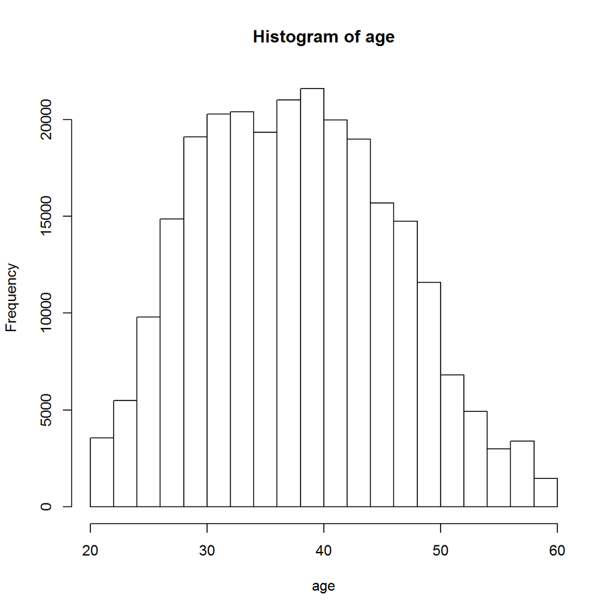

```r
  hist(servicex$age, main="Histogram of age", xlab="age")
```

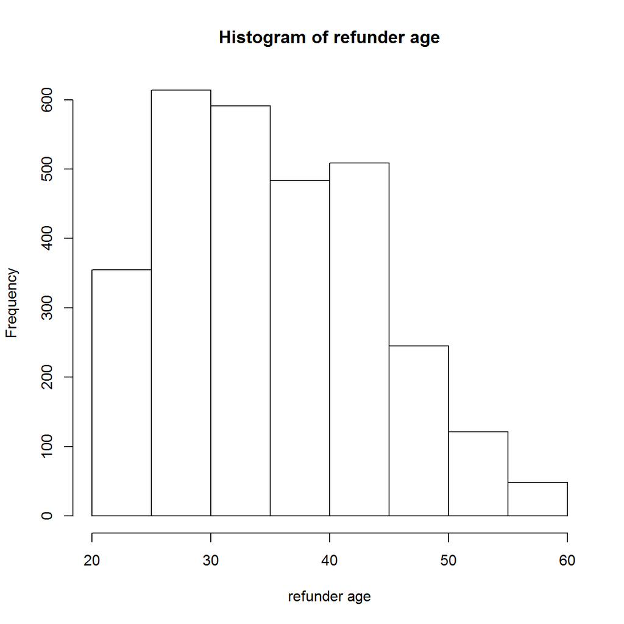

```r
  hist(subset(servicex,status=="REFUNDED")$age, main="Histogram of refunder age", xlab="refunder age")
```

> - 서비스 X 주요 사용 연령대는 30대~40대초반
> - 환불 고객의 연령 분포가 전체 연령 분포에 비해 왼쪽으로 치우침
> - 평균차이가 있을것으로 추정됨
> - 가설검정 실시 (t-test)
> - [H0 : 환불고객과 미환불 구매 고객의 (평균)연령은 같다.]
> - [H1 : 환불고객은 미환불 구매 고객의 (평균)연령은 다르다.]

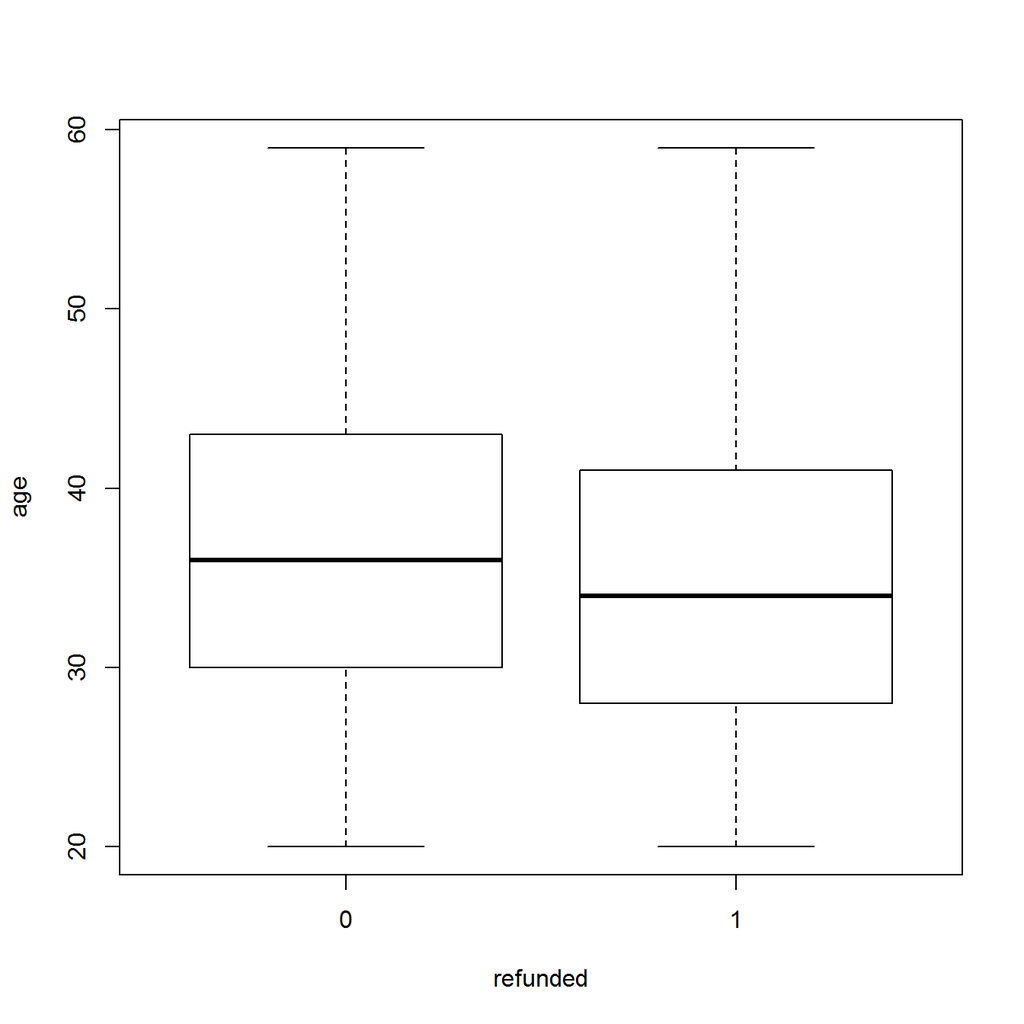

```r
  refuser <- unique(servicex[which(servicex$status=="REFUNDED"),"uid"])
  comuser <- unique(servicex[which(servicex$status=="COMPLETED"),"uid"])
  comuser <- comuser[which(is.na(match(comuser,refuser)))]

  refuser <- cbind(servicex[match(refuser,servicex$uid),], "ref"=1)
  comuser <- cbind(servicex[match(comuser,servicex$uid),], "ref"=0)

  refuser_binary <- rbind(refuser,comuser)
  boxplot(age ~ ref, data=refuser_binary, xlab="refunded")
```

```r
  var.test(age ~ ref, data=refuser_binary)
```

```
##
##  F test to compare two variances
##
## data:  age by ref
## F = 0.99937, num df = 25925, denom df = 2137, p-value = 0.977
## alternative hypothesis: true ratio of variances is not equal to 1
## 95 percent confidence interval:
##  0.9381329 1.0628226
## sample estimates:
## ratio of variances
##          0.9993687
```

```r
  t.test(age ~ ref, data=refuser_binary, alternative="two.sided", var.equal=T, conf.level=0.95)
```

```
##
##  Two Sample t-test
##
## data:  age by ref
## t = 7.9026, df = 28062, p-value = 2.831e-15
## alternative hypothesis: true difference in means is not equal to 0
## 95 percent confidence interval:
##  1.164193 1.932169
## sample estimates:
## mean in group 0 mean in group 1
##        36.76988        35.22170
```

> - 통계적으로 유의하게 평균차이가 있다고 할 수 있음
> - 인과관계로 확대하기 위해 로지스틱 회귀 모형 확인
> - [가설 : 연령이 낮을수록 환불할 가능성이 높다.]

```r
  model11x <- glm(ref ~ age + gender_cd, data=refuser_binary, family=binomial(link="logit"))
  anova(model11x, test="Chisq")
```

```
## Analysis of Deviance Table
##
## Model: binomial, link: logit
##
## Response: ref
##
## Terms added sequentially (first to last)
##
##
##           Df Deviance Resid. Df Resid. Dev  Pr(>Chi)
## NULL                      28063      15118
## age        1   63.603     28062      15054 1.522e-15 ***
## gender_cd  1    0.000     28061      15054    0.9974
## ---
## Signif. codes:  0 '***' 0.001 '**' 0.01 '*' 0.05 '.' 0.1 ' ' 1
```

```r
  summary(model11x)
```

```
##
## Call:
## glm(formula = ref ~ age + gender_cd, family = binomial(link = "logit"),
##     data = refuser_binary)
##
## Deviance Residuals:
##     Min       1Q   Median       3Q      Max
## -0.4674  -0.4229  -0.3940  -0.3633   2.4614
##
## Coefficients:
##               Estimate Std. Error z value Pr(>|z|)
## (Intercept) -1.7384344  0.1203569 -14.444  < 2e-16 ***
## age         -0.0210411  0.0026739  -7.869 3.58e-15 ***
## gender_cd    0.0001518  0.0463701   0.003    0.997
## ---
## Signif. codes:  0 '***' 0.001 '**' 0.01 '*' 0.05 '.' 0.1 ' ' 1
##
## (Dispersion parameter for binomial family taken to be 1)
##
##     Null deviance: 15118  on 28063  degrees of freedom
## Residual deviance: 15054  on 28061  degrees of freedom
## AIC: 15060
##
## Number of Fisher Scoring iterations: 5
```

> - 환불 가능성에 대해 연령이 유의미하게 영향을 미치는 것으로 판단됨
> - 연령의 추정계수가 -0.02로 유의함(오즈값이 1 미만)
> - 연령이 낮을수록 환불할 가능성이 높다고 판단됨

### **TASK 2**

### Funnel

```r
  grp <- servicex$gender_cd
  grp <- servicex$channel
  grp <- format(servicex$product_end_at,"%Y-%m")
  grp <- format(servicex$created_at,"%Y-%m")

  funnel <- dcast(funnel ~ grp, data=data.frame(with(servicex, table(funnel,grp))), value.var="Freq")
  fnrate <- data.frame(round(cbind(c(funnel[1:3,2]/funnel[1,2],funnel[4:5,2]/funnel[3,2])
                                   ,c(funnel[1:3,3]/funnel[1,3],funnel[4:5,3]/funnel[3,3]))
                             ,4)*100
                       ,row.names=c("Ready", "Failed", "Completed", "Canceled", "Refunded"))
  colnames(fnrate) <- names(table(grp))
  fnrate
```

```
##           2019-04 2019-05
## Ready      100.00  100.00
## Failed       1.20    0.95
## Completed   98.79   99.02
## Canceled     2.34    2.45
## Refunded     2.34    2.45
```

> $실패비율=\frac{실패건수}{준비건수}$, $구매비율=\frac{구매건수}{준비건수}$  
> $취소비율=\frac{취소건수}{구매건수}$, $환불비율=\frac{환불건수}{구매건수}$
> - 실패비율과 구매비율 값이 4월과 5월에 각각 차이를 보임
> - 유의미한 차이가 있을지 일별로 확인할 필요가 있음

```r
  funneld <- dcast(Var1 ~ Var2
                   , data=data.frame(table(servicex$funnel,format(servicex$created_at,"%Y-%m-%d")))
                   , value.var="Freq")
```

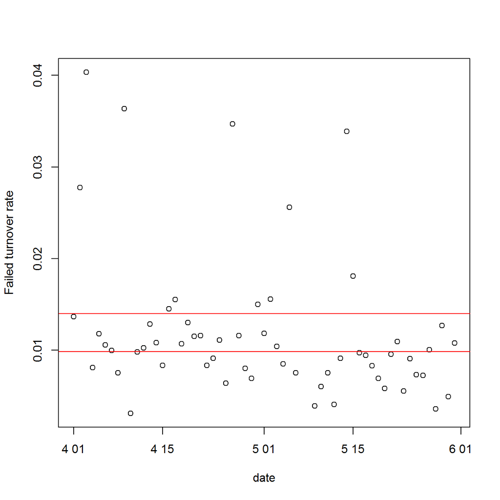

```r
  turnover <- t(funneld[2,-1]/funneld[1,-1])
  plot(as.Date(rownames(turnover)),turnover, xlab="date", ylab="Failed turnover rate")
  abline(h=t.test(turnover)$conf.int[1:2], col="red")
```

```r
  rownames(turnover)[turnover>=t.test(turnover)$conf.int[2]]
```

```
##  [1] "2019-04-02" "2019-04-03" "2019-04-09" "2019-04-16" "2019-04-17"
##  [6] "2019-04-26" "2019-04-30" "2019-05-02" "2019-05-05" "2019-05-14"
## [11] "2019-05-15"
```

> - 실패 전환율 시계열 그래프에서 신뢰구간(빨간라인)을 벗어나게 높은 날이 다수 확인됨
> - 해당 일자(4월 2일 외 10일)에 실패율에 영향을 미쳤던 요소 확인 필요

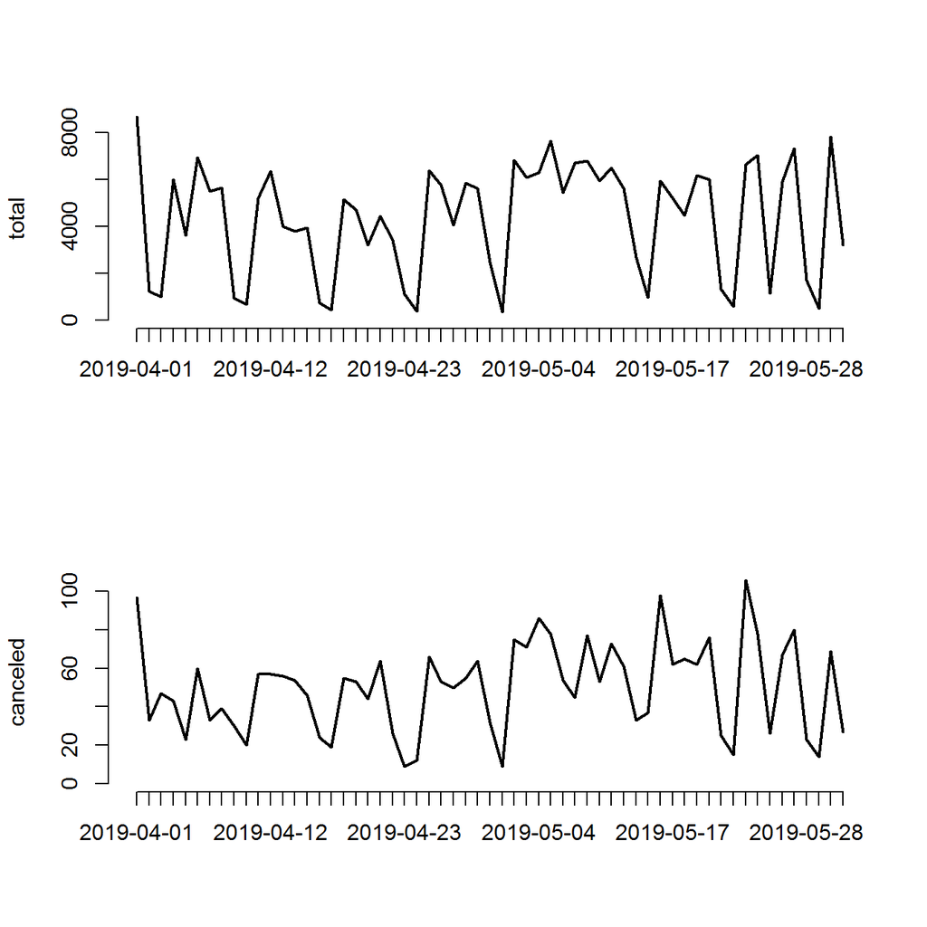

```r
  servicexCC <- subset(servicex, status=="CANCELED")

  par(mfrow=c(2,1))
  plot(with(servicex, table(format(created_at,"%Y-%m-%d"))), type="l", ylab="total")
  plot(with(servicexCC, table(format(created_at,"%Y-%m-%d"))), type="l", ylab="canceled")
```

> (상단) 전체 트래픽  
> (하단) 취소트래픽  
> - 육안상 큰 차이 확인 불가, 다른 분석방안 필요

```r
  with(servicex, table(difftime(created_at[which(status=="FAILED")]
                                ,created_at[which(status=="FAILED")-1],units="secs")))
```

```
##
##    0    1    2    3   11   33   34   35   37   59   60   61  480 1001 1007
##  384  867   54    5    3    1    1    3    1    2    1    1    1    1    1
## 1074
##    1
```

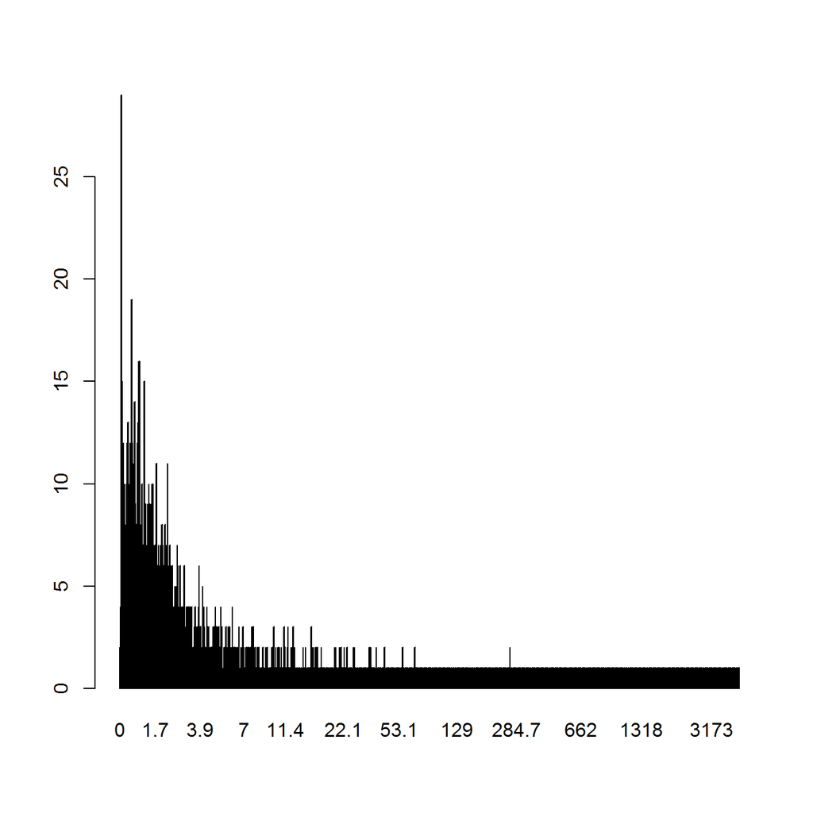

```r
  with(servicex, barplot(table(difftime(created_at[which(status=="CANCELED")]
                                        ,created_at[which(status=="CANCELED")-1],units="min"))))
```

> - 실패 트래픽은 준비 후 거의 5초 내 발생 : 원인파악 필요
> - 취소 트래픽은 구매 후 5분 내 발생 : 환불치 않게 유도 필요

### Count model - Expected Completed

```r
  countx <- data.frame("uid"=rownames(with(servicex, table(uid,status))),
                       "ncomplete"=with(servicex, table(uid,status))[,"COMPLETED"],
                       "age"=servicex[match(rownames(with(servicex, table(uid,status)))
                                            ,servicex$uid),"age"],
                       "gender"=servicex[match(rownames(with(servicex, table(uid,status)))
                                               ,servicex$uid),"gender_cd"])
  model21x <- glm(ncomplete ~ age + gender, data=countx, family=poisson(link="log"))
  summary(model21x)
```

```
##
## Call:
## glm(formula = ncomplete ~ age + gender, family = poisson(link = "log"),
##     data = countx)
##
## Deviance Residuals:
##    Min      1Q  Median      3Q     Max
## -3.916  -1.869  -1.243  -0.064  36.810
##
## Coefficients:
##             Estimate Std. Error z value Pr(>|z|)
## (Intercept) 0.044476   0.016250   2.737   0.0062 **
## age         0.019963   0.000319  62.588   <2e-16 ***
## gender      0.407318   0.006283  64.825   <2e-16 ***
## ---
## Signif. codes:  0 '***' 0.001 '**' 0.01 '*' 0.05 '.' 0.1 ' ' 1
##
## (Dispersion parameter for poisson family taken to be 1)
##
##     Null deviance: 205475  on 28406  degrees of freedom
## Residual deviance: 196876  on 28404  degrees of freedom
## AIC: 274384
##
## Number of Fisher Scoring iterations: 6
```

```r
  exp(model21x$coef)
```

```
## (Intercept)         age      gender
##    1.045480    1.020163    1.502782
```

> - 유저별 구매횟수에 영향을 미치는 요인 확인을 위한 포아송회귀모형 구축
> - 연령이 높아질수록 기대구매횟수가 높아짐
> - 성별 2가 성별 1에 비해 기대구매횟수가 높음

### **TASK 3 SQL**

> - R에서 DB 연결후 자체함수를 활용해 Query 전달

```r
  connection <- dbConnect(SQLite(),dbname=paste(dpath,"DataBase.sqlite",sep="\\"))


  q3_1 <- dbGetQuery(connection,"
                     SELECT uid, count(uid)
                      FROM (SELECT *
                        FROM (SELECT *
                          FROM (SELECT *
                                  FROM x_transaction_history tist
                                  LEFT OUTER JOIN x_users users ON tist.uid=users.uid
                                  LEFT OUTER JOIN x_product prod ON tist.pid=prod.pid
                          )
                          WHERE amount >= 100000
                          GROUP BY uid, pid, status
                        )
                        GROUP BY uid, pid
                        HAVING count(status)<4 AND status IN ('COMPLETED')
                      )
                      GROUP BY uid
                      HAVING count(uid)>=10
                     ")
  head(q3_1);nrow(q3_1)
```

```
##    uid count(uid)
## 1  123         32
## 2  346         38
## 3  764         31
## 4 1296         17
## 5 1442         24
## 6 2177         23
```

```
## [1] 1987
```

```r
  q3_2 <- dbGetQuery(connection,"
                     SELECT uid, count(uid)
                      FROM (SELECT *
                        FROM (SELECT *
                          FROM (SELECT *
                                  FROM x_transaction_history tist
                                  LEFT OUTER JOIN x_users users ON tist.uid=users.uid
                                  LEFT OUTER JOIN x_product prod ON tist.pid=prod.pid
                          )
                          WHERE amount >= 100000
                          GROUP BY uid, pid, status
                        )
                        GROUP BY uid, pid
                        HAVING count(status)<4 AND status IN ('COMPLETED')
                      )
                      GROUP BY uid
                      HAVING count(uid)>=5 AND count(uid)<10
                     ")
  head(q3_2);nrow(q3_2)
```

```
##   uid count(uid)
## 1 175          5
## 2 211          8
## 3 249          5
## 4 366          8
## 5 405          6
## 6 493          6
```

```
## [1] 2823
```

```r
  sum(match(q3_1$uid,q3_2$uid))
```

```
## [1] NA
```

# **(2nd) Dutch pay**

### Data Input

```r
  dutchclaim <- read.csv(paste(dpath, "dutchpay_claim_tx.csv", sep="\\"), header=T, stringsAsFactors=F)
  dutchdetail <- read.csv(paste(dpath, "dutchpay_claim_detail.csv", sep="\\"), header=T, stringsAsFactors=F)

  dutchpay <- merge(dutchdetail, dutchclaim, all.x=T, all.y=F, by.x="remittance_claim_send_id", by.y="id")
    dutchpay$created_at.x <- as.POSIXct(dutchpay$created_at.x, format="%Y-%m-%dT%H:%M:%SZ")
    dutchpay$created_at.y <- as.POSIXct(dutchpay$created_at.y, format="%Y-%m-%dT%H:%M:%SZ")

    dutchpay <- cbind(dutchpay
                      , "position"=apply(dutchpay[,c("user_id.x", "user_id.y")]
                                         , 1
                                         , function(x) {ifelse(x[1]==x[2],"creditor","deptor")}
                      )
    )
```

```r
  kable(head(dutchpay)) %>% kable_styling(font_size = 10)
```

| remittance_claim_send_id | id | created_at.x | user_id.x | claim_amount | send_amount | status | send_transaction_event_id | created_at.y | user_id.y | position |
| --- | --- | --- | --- | --- | --- | --- | --- | --- | --- | --- |
| 3710942 | 11640175 | 2019-12-01 00:00:07 | bedd7ab091b6e84 | 18666 | NA | CLAIM | NA | 2019-12-01 00:00:07 | eb2349f4559aff8 | deptor |
| 3710942 | 11640176 | 2019-12-01 00:00:07 | 4d9a7a49c9bb983 | 18666 | NA | CLAIM | NA | 2019-12-01 00:00:07 | eb2349f4559aff8 | deptor |
| 3710942 | 11640174 | 2019-12-01 00:00:07 | eb2349f4559aff8 | 18666 | 18666 | CHECK | NA | 2019-12-01 00:00:07 | eb2349f4559aff8 | creditor |
| 3710943 | 11640177 | 2019-12-01 00:00:08 | f5798f1972bf7b8 | 27500 | 27500 | CHECK | NA | 2019-12-01 00:00:08 | f5798f1972bf7b8 | creditor |
| 3710943 | 11640181 | 2019-12-01 00:00:08 | 24ea6f9bb997230 | 27500 | 27500 | SEND | 1782519707 | 2019-12-01 00:00:08 | f5798f1972bf7b8 | deptor |
| 3710943 | 11640180 | 2019-12-01 00:00:08 | 2537ec708b33986 | 27500 | 27500 | SEND | 1782425972 | 2019-12-01 00:00:08 | f5798f1972bf7b8 | deptor |

```r
  str(dutchpay)
```

```
## 'data.frame':    3413602 obs. of  11 variables:
##  $ remittance_claim_send_id : int  3710942 3710942 3710942 3710943 3710943 3710943 3710943 3710943 3710944 3710945 ...
##  $ id                       : int  11640175 11640176 11640174 11640177 11640181 11640180 11640178 11640179 11640182 11640185 ...
##  $ created_at.x             : POSIXct, format: "2019-12-01 00:00:07" "2019-12-01 00:00:07" ...
##  $ user_id.x                : chr  "bedd7ab091b6e84" "4d9a7a49c9bb983" "eb2349f4559aff8" "f5798f1972bf7b8" ...
##  $ claim_amount             : int  18666 18666 18666 27500 27500 27500 27500 27500 18900 0 ...
##  $ send_amount              : int  NA NA 18666 27500 27500 27500 27500 NA NA NA ...
##  $ status                   : chr  "CLAIM" "CLAIM" "CHECK" "CHECK" ...
##  $ send_transaction_event_id: num  NA NA NA NA 1782519707 ...
##  $ created_at.y             : POSIXct, format: "2019-12-01 00:00:07" "2019-12-01 00:00:07" ...
##  $ user_id.y                : chr  "eb2349f4559aff8" "eb2349f4559aff8" "eb2349f4559aff8" "f5798f1972bf7b8" ...
##  $ position                 : Factor w/ 2 levels "creditor","deptor": 2 2 1 1 2 2 2 2 2 2 ...
```

> - 더치페이 요청자와 부담자를 구분

### **TASK 1**

```r
  dutchpay %>% filter(position=="creditor") %>% group_by(status) %>% summarise(mean(claim_amount))
```

```
## # A tibble: 1 x 2
##   status `mean(claim_amount)`
##   <chr>                 <dbl>
## 1 CHECK                44265.
```

```r
  dutchpay %>% filter(position=="deptor") %>% group_by(status) %>% summarise(mean(claim_amount))
```

```
## # A tibble: 3 x 2
##   status `mean(claim_amount)`
##   <chr>                 <dbl>
## 1 CHECK                10900
## 2 CLAIM                51104.
## 3 SEND                 16119.
```

```r
  dept0 <- subset(dutchpay, position=="deptor" & status=="CLAIM")$claim_amount
  dept1 <- subset(dutchpay, position=="deptor" & status=="SEND")$claim_amount

  var.test(dept0, dept1)
```

```
##
##  F test to compare two variances
##
## data:  dept0 and dept1
## F = 1811.3, num df = 1512325, denom df = 992526, p-value < 2.2e-16
## alternative hypothesis: true ratio of variances is not equal to 1
## 95 percent confidence interval:
##  1806.253 1816.332
## sample estimates:
## ratio of variances
##           1811.289
```

```r
  t.test(dept0, dept1, alternative="two.sided", var.equal=F)
```

```
##
##  Welch Two Sample t-test
##
## data:  dept0 and dept1
## t = 8.5255, df = 1514869, p-value < 2.2e-16
## alternative hypothesis: true difference in means is not equal to 0
## 95 percent confidence interval:
##  26942.29 43028.05
## sample estimates:
## mean of x mean of y
##  51103.89  16118.71
```

> - 더치페이 부담인의 송금완료시 평균 부담액과 송금미완료시 평균 부담액 평균이 다름
> - [H0: 송금완료시 금액과 송금미완료시 금액에 차이가 없다.]
> - [H1: 송금완료시 금액과 송금미완료시 금액에 차이가 있다.]
> - 송금 미완료시 금액이 유의미하게 더 큰 것으로 나타남
> - 즉, 요청단가가 클수록 페이 잔고부족 인한 이탈(다른 송금 방법 선택) 가능성이 있을 것으로 추측

```r
  dept_binary <- subset(dutchpay, position=="deptor" & status!="CHECK")
  model11d <- glm(status=="CLAIM" ~ claim_amount, data=dept_binary, family=binomial(link="logit"))
  summary(model11d)
```

```
##
## Call:
## glm(formula = status == "CLAIM" ~ claim_amount, family = binomial(link = "logit"),
##     data = dept_binary)
##
## Deviance Residuals:
##    Min      1Q  Median      3Q     Max
## -8.490  -1.350   1.002   1.014   1.021
##
## Coefficients:
##                   Estimate    Std. Error z value Pr(>|z|)
## (Intercept)  0.38000549078 0.00139753297  271.91   <2e-16 ***
## claim_amount 0.00000202499 0.00000003122   64.86   <2e-16 ***
## ---
## Signif. codes:  0 '***' 0.001 '**' 0.01 '*' 0.05 '.' 0.1 ' ' 1
##
## (Dispersion parameter for binomial family taken to be 1)
##
##     Null deviance: 3363809  on 2504852  degrees of freedom
## Residual deviance: 3351133  on 2504851  degrees of freedom
## AIC: 3351137
##
## Number of Fisher Scoring iterations: 9
```

> - 로지스틱 회귀모형으로 인과관계 확인
> - 송금여부에 요청단가가 유의미한 영향이 있음
> - 추정 오즈 값이 거의 1에 가까움
> - 좀 더 정확한 영향정도 확인을 위한 데이터 추가 필요

### **TASK 2**

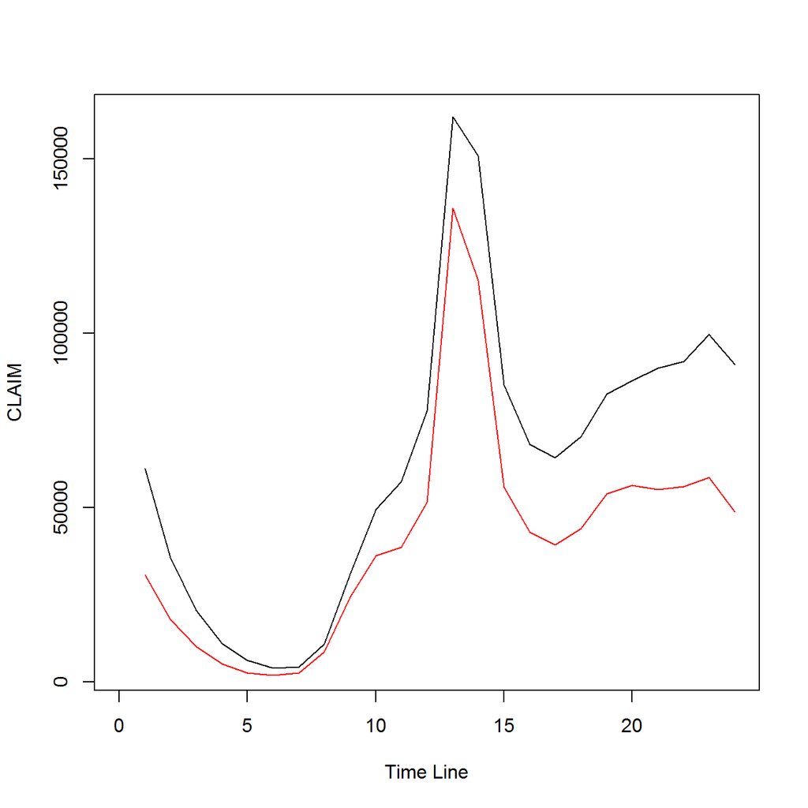

```r
  deptor <- dutchpay %>% filter(position=="deptor")

  hourtable <- dcast(Var1 ~ status
                     , data=data.frame(with(deptor, table(format(deptor$created_at.x,"%H"),status)))
                     , value.var="Freq")
    hourtable <- hourtable %>% mutate(SRate=SEND/(CLAIM+SEND))
  with(hourtable, plot(CLAIM,type="l", col="black", xlim=c(0,24), xlab="Time Line"))
  with(hourtable, lines(SEND,type="l", col="red"))
```

> - (검정 꺾은선) 하루 중 요청시간대별 송금미완료 건수 변화
> - (빨간 꺾은선) 하루 중 요청시간대별 송금완료 건수 변화

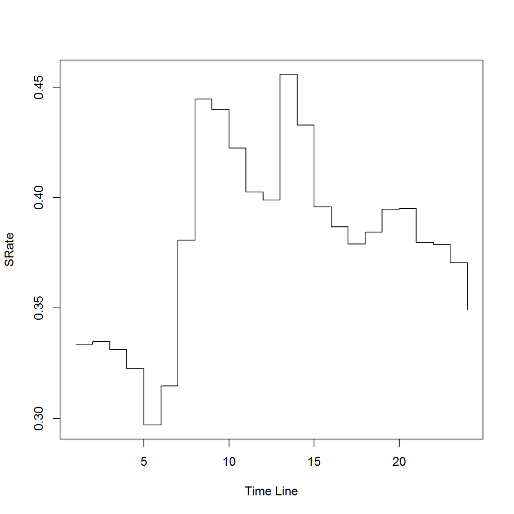

```r
  with(hourtable, plot(SRate,type="s", xlab="Time Line"))
```

### **TASK 4**

```r
  depts <- dutchpay %>% filter(position=="deptor") %>% group_by(remittance_claim_send_id,status) %>% summarise(total=n()) %>% group_by(remittance_claim_send_id) %>% mutate(percent=total/sum(total))
    depts <- subset(depts, status=="SEND")

  deptmount <- dutchpay %>% filter(position=="deptor") %>% group_by(remittance_claim_send_id) %>% summarise(amount=sum(claim_amount))
  remittance <- dutchpay %>% filter(position=="creditor") %>% group_by(user_id.y,remittance_claim_send_id) %>% summarise(n())

  resp <- merge(remittance, depts
                , by="remittance_claim_send_id",all=T)[,c("remittance_claim_send_id","user_id.y","percent")]
    resp <- resp[!is.na(resp$user_id.y),]
    resp <- merge(resp, deptmount, by="remittance_claim_send_id", all.x=T, all.y=F)
    resp[is.na(resp$percent),"percent"] <- 0.01
    resp[is.na(resp$amount),"amount"] <- 1
    resp <- resp %>% arrange(user_id.y, remittance_claim_send_id)
    resp <- cbind(resp, "freq"=1) %>% group_by(user_id.y) %>% mutate(seq=cumsum(freq))

  kable(head(resp)) %>% kable_styling(font_size = 10)
```

| remittance_claim_send_id | user_id.y | percent | amount | freq | seq |
| --- | --- | --- | --- | --- | --- |
| 4026105 | 00001d2012b1b7b | 0.0100000 | 28000 | 1 | 1 |
| 4036116 | 00001d2012b1b7b | 0.0100000 | 3500 | 1 | 2 |
| 4366339 | 0000f7cd8d41230 | 0.7500000 | 52160 | 1 | 1 |
| 4553230 | 0001220f2933b14 | 0.6666667 | 22000 | 1 | 1 |
| 4200637 | 0001440cbac4d21 | 0.0100000 | 21332 | 1 | 1 |
| 4342188 | 000148e0ea7f476 | 0.0100000 | 1 | 1 | 1 |

> - 송금요청 1건당 회수율 계산 (percent 변수)

```r
  respR <- cbind(aggregate(percent ~ user_id.y, data=resp, mean)
                 ,"N"=aggregate(percent ~ user_id.y, data=resp, length)[,2])
  kable(head(respR)) %>% kable_styling(font_size = 10)
```

| user_id.y | percent | N |
| --- | --- | --- |
| 00001d2012b1b7b | 0.0100000 | 2 |
| 0000f7cd8d41230 | 0.7500000 | 1 |
| 0001220f2933b14 | 0.6666667 | 1 |
| 0001440cbac4d21 | 0.0100000 | 1 |
| 000148e0ea7f476 | 0.0100000 | 5 |
| 0001a5e891b0880 | 0.7525000 | 4 |

> - 서비스 이용자별 송금요청 회수율 평균 계산

```r
  ## count model
  model41 <-lm(N ~ log(percent), data=respR)
  summary(model41)
```

```
##
## Call:
## lm(formula = N ~ log(percent), data = respR)
##
## Residuals:
##     Min      1Q  Median      3Q     Max
##  -2.786  -1.786  -0.972   0.028 172.028
##
## Coefficients:
##              Estimate Std. Error t value Pr(>|t|)
## (Intercept)  3.785788   0.010659   355.2   <2e-16 ***
## log(percent) 0.393880   0.003674   107.2   <2e-16 ***
## ---
## Signif. codes:  0 '***' 0.001 '**' 0.01 '*' 0.05 '.' 0.1 ' ' 1
##
## Residual standard error: 3.89 on 311041 degrees of freedom
## Multiple R-squared:  0.03563,    Adjusted R-squared:  0.03563
## F-statistic: 1.149e+04 on 1 and 311041 DF,  p-value: < 2.2e-16
```

```r
  model42 <- glm(N ~ log(percent), data=respR, family=poisson(link="log"))
  anova(model42)
```

```
## Analysis of Deviance Table
##
## Model: poisson, link: log
##
## Response: N
##
## Terms added sequentially (first to last)
##
##
##              Df Deviance Resid. Df Resid. Dev
## NULL                        311042     905722
## log(percent)  1    62132    311041     843590
```

```r
  summary(model42);exp(coef(model42))
```

```
##
## Call:
## glm(formula = N ~ log(percent), family = poisson(link = "log"),
##     data = respR)
##
## Deviance Residuals:
##    Min      1Q  Median      3Q     Max
## -1.742  -1.049  -0.776   0.009  34.817
##
## Coefficients:
##               Estimate Std. Error z value Pr(>|z|)
## (Intercept)  1.3535544  0.0014668   922.8   <2e-16 ***
## log(percent) 0.1447273  0.0006001   241.2   <2e-16 ***
## ---
## Signif. codes:  0 '***' 0.001 '**' 0.01 '*' 0.05 '.' 0.1 ' ' 1
##
## (Dispersion parameter for poisson family taken to be 1)
##
##     Null deviance: 905722  on 311042  degrees of freedom
## Residual deviance: 843590  on 311041  degrees of freedom
## AIC: 1652503
##
## Number of Fisher Scoring iterations: 5
```

```
##  (Intercept) log(percent)
##     3.871161     1.155724
```

```r
  ### model43 <- glm.nb(N ~ log(percent), data=respR)
  ### anova(model43)
  ### summary(model43);exp(coef(model43))

  ### model44 <- vglm(N ~ log(percent), data=respR, family=posnegbinomial())
  ### summary(model44)
```

```r
  ## Binary model
  respR <- respR %>% mutate(Bin=N>1)

  model45 <- glm(Bin ~ log(percent), data=respR, family=binomial(link="logit"))
  anova(model45)
```

```
## Analysis of Deviance Table
##
## Model: binomial, link: logit
##
## Response: Bin
##
## Terms added sequentially (first to last)
##
##
##              Df Deviance Resid. Df Resid. Dev
## NULL                        311042     431195
## log(percent)  1    20041    311041     411154
```

```r
  summary(model45)
```

```
##
## Call:
## glm(formula = Bin ~ log(percent), family = binomial(link = "logit"),
##     data = respR)
##
## Deviance Residuals:
##     Min       1Q   Median       3Q      Max
## -1.4361  -0.9094  -0.9094   1.0551   1.4715
##
## Coefficients:
##              Estimate Std. Error z value Pr(>|z|)
## (Intercept)  0.590205   0.005628   104.9   <2e-16 ***
## log(percent) 0.273463   0.001975   138.4   <2e-16 ***
## ---
## Signif. codes:  0 '***' 0.001 '**' 0.01 '*' 0.05 '.' 0.1 ' ' 1
##
## (Dispersion parameter for binomial family taken to be 1)
##
##     Null deviance: 431195  on 311042  degrees of freedom
## Residual deviance: 411154  on 311041  degrees of freedom
## AIC: 411158
##
## Number of Fisher Scoring iterations: 4
```

```r
  ## panel AR
  respP <- as.data.frame(resp[!is.na(match(resp$user_id.y,subset(respR, N>=3)$user_id.y)),])

  model46 <- panelAR(seq ~ percent + amount
                     , data=respP[!is.na(match(respP$user_id.y
                                               , sample(unique(respP$user_id.y),1000,replace=F))),]
                     , panelVar="user_id.y", timeVar="seq", autoCorr="ar1", panelCorrMethod="pwls")
  summary(model46)
```

```
##
## Panel Regression with AR(1) Prais-Winsten correction and panel weighted least squares
##
## Unbalanced Panel Design:
##  Total obs.:       6698 Avg obs. per panel 6.698
##  Number of panels: 1000 Max obs. per panel 110
##  Number of times:  110  Min obs. per panel 3
##
## Coefficients:
##                   Estimate     Std. Error t value Pr(>|t|)
## (Intercept)  3.78647709684  0.06322788058  59.886   <2e-16 ***
## percent      0.11054339523  0.04718816624   2.343   0.0192 *
## amount      -0.00000002001  0.00000004319  -0.463   0.6431
## ---
## Signif. codes:  0 '***' 0.001 '**' 0.01 '*' 0.05 '.' 0.1 ' ' 1
##
## Wald statistic: 5.7343, Pr(>Chisq(2)): 0.0569
```

> - 직전 회수율이 다음 서비스 이용에 영향을 준다고 가정함
> - 이용횟수 3회 이상인 회원 중 임의추출 1,000명 패널데이터(respP 객체)
> - 패널자기회귀모형 구축
> - 직전 회수율은 서비스 이용에 영향을 준다고 판단됨
> - [가설 : 응답율이 높으면 더치패이를 더 자주 이용한다.]
> - 첫째, 포아송회귀 : 평균회수율과 기대이용횟수
> - 둘째, 로지스틱회귀 : 평균회수율과 다회이용여부
> - 셋째, 패널자기회귀 : 이전경험, 개인적특성과 이용빈도
> - 결론, 회수율은 유의미한 영향이 있다고 판단됨

### **TASK 5. Serial Retention**

```r
  creditor <- dutchpay %>% filter(position=="creditor")
    table(format(creditor$created_at.y, "%Y-%m"))
```

```
##
## 2019-12 2020-01 2020-02
##  281186  305727  321832
```

```r
  dterm <- unique(format(creditor$created_at.y, "%Y-%m-%d"))
    length(as.Date(dterm[1]):as.Date(dterm[length(dterm)]))
```

```
## [1] 91
```

```r
  dtable <- matrix(as.character(as.Date(0:(length(as.Date(dterm[1]):as.Date(dterm[length(dterm)]))-1)
                                        , origin=dterm[1]))
                   , ncol=7, byrow=T)
  kable(head(dtable)) %>% kable_styling(font_size = 10)
```

| 2019-12-01 | 2019-12-02 | 2019-12-03 | 2019-12-04 | 2019-12-05 | 2019-12-06 | 2019-12-07 |
| --- | --- | --- | --- | --- | --- | --- |
| 2019-12-08 | 2019-12-09 | 2019-12-10 | 2019-12-11 | 2019-12-12 | 2019-12-13 | 2019-12-14 |
| 2019-12-15 | 2019-12-16 | 2019-12-17 | 2019-12-18 | 2019-12-19 | 2019-12-20 | 2019-12-21 |
| 2019-12-22 | 2019-12-23 | 2019-12-24 | 2019-12-25 | 2019-12-26 | 2019-12-27 | 2019-12-28 |
| 2019-12-29 | 2019-12-30 | 2019-12-31 | 2020-01-01 | 2020-01-02 | 2020-01-03 | 2020-01-04 |
| 2020-01-05 | 2020-01-06 | 2020-01-07 | 2020-01-08 | 2020-01-09 | 2020-01-10 | 2020-01-11 |

> - 데이터 전체 기간에 대한 주 단위 달력 준비(dtable 객체)

```r
  creditor <- cbind(creditor, "init"=NA, "nweek"=NA, "cohort"=NA)
    creditor[duplicated(creditor$user_id.y)==F,"init"] <- "init"
    creditor[duplicated(creditor$user_id.y)==T,"init"] <- "retention"
    creditor$nweek <- paste("week"
                            ,ceiling((as.numeric(as.Date(format(creditor$created_at.y, "%Y-%m-%d")))-18230)/7))

  for(k in 1:nrow(dtable)) {
    creditor[which(creditor$init=="init"
                   &(as.numeric(as.Date(format(creditor$created_at.y
                                               ,"%Y-%m-%d")))>=as.numeric(as.Date(dtable[k,1]))
                      & as.numeric(as.Date(format(creditor$created_at.y
                                                  ,"%Y-%m-%d")))<=as.numeric(as.Date(dtable[k,7]))
                      ))
             ,"cohort"] <- paste("cohort",k)
  }
  creditor[which(creditor$init=="retention")
           ,"cohort"] <- creditor[match(creditor[which(creditor$init=="retention"),"user_id.y"]
                                        ,creditor$user_id.y),"cohort"]
    creditor$cohort <- factor(creditor$cohort, levels=paste("cohort",1:nrow(dtable)))
    creditor$nweek <- factor(creditor$nweek, levels=paste("week",1:nrow(dtable)))

  lnd_retention <- data.frame(with(creditor, table(cohort,nweek)))
    lnd_retention[which(lnd_retention$Freq==0),"Freq"]<-NA
  mat_retention <- dcast(lnd_retention, cohort ~ nweek, value.var="Freq")
  mat_retentionR <- round((mat_retention / diag(as.matrix(mat_retention[,-1])))[,-1],4)
  kable(mat_retention) %>% kable_styling(font_size = 10)
```

| cohort | week 1 | week 2 | week 3 | week 4 | week 5 | week 6 | week 7 | week 8 | week 9 | week 10 | week 11 | week 12 | week 13 |
| --- | --- | --- | --- | --- | --- | --- | --- | --- | --- | --- | --- | --- | --- |
| cohort 1 | 67091 | 16096 | 20100 | 20357 | 17197 | 18179 | 17856 | 17271 | 18402 | 18710 | 17897 | 17578 | 19405 |
| cohort 2 | NA | 38354 | 8267 | 8055 | 6683 | 7533 | 6862 | 6466 | 7148 | 6846 | 6936 | 6841 | 7595 |
| cohort 3 | NA | NA | 39659 | 7891 | 6288 | 6418 | 6423 | 6182 | 6458 | 6245 | 6462 | 6323 | 6834 |
| cohort 4 | NA | NA | NA | 35891 | 5120 | 5320 | 4955 | 4917 | 5091 | 4785 | 4832 | 4900 | 5461 |
| cohort 5 | NA | NA | NA | NA | 27184 | 3973 | 3468 | 3118 | 3388 | 3435 | 3363 | 3157 | 3645 |
| cohort 6 | NA | NA | NA | NA | NA | 27739 | 3412 | 3122 | 3241 | 3045 | 3039 | 3024 | 3376 |
| cohort 7 | NA | NA | NA | NA | NA | NA | 24184 | 3200 | 2944 | 2879 | 2761 | 2628 | 2905 |
| cohort 8 | NA | NA | NA | NA | NA | NA | NA | 21982 | 2907 | 2502 | 2467 | 2488 | 2621 |
| cohort 9 | NA | NA | NA | NA | NA | NA | NA | NA | 22712 | 2867 | 2663 | 2437 | 2765 |
| cohort 10 | NA | NA | NA | NA | NA | NA | NA | NA | NA | 21820 | 2716 | 2330 | 2482 |
| cohort 11 | NA | NA | NA | NA | NA | NA | NA | NA | NA | NA | 21493 | 2593 | 2525 |
| cohort 12 | NA | NA | NA | NA | NA | NA | NA | NA | NA | NA | NA | 20565 | 2634 |
| cohort 13 | NA | NA | NA | NA | NA | NA | NA | NA | NA | NA | NA | NA | 24766 |

```r
  kable(mat_retentionR) %>% kable_styling(font_size = 10)
```

| week 1 | week 2 | week 3 | week 4 | week 5 | week 6 | week 7 | week 8 | week 9 | week 10 | week 11 | week 12 | week 13 |
| --- | --- | --- | --- | --- | --- | --- | --- | --- | --- | --- | --- | --- |
| 1 | 0.2399 | 0.2996 | 0.3034 | 0.2563 | 0.2710 | 0.2661 | 0.2574 | 0.2743 | 0.2789 | 0.2668 | 0.2620 | 0.2892 |
| NA | 1.0000 | 0.2155 | 0.2100 | 0.1742 | 0.1964 | 0.1789 | 0.1686 | 0.1864 | 0.1785 | 0.1808 | 0.1784 | 0.1980 |
| NA | NA | 1.0000 | 0.1990 | 0.1586 | 0.1618 | 0.1620 | 0.1559 | 0.1628 | 0.1575 | 0.1629 | 0.1594 | 0.1723 |
| NA | NA | NA | 1.0000 | 0.1427 | 0.1482 | 0.1381 | 0.1370 | 0.1418 | 0.1333 | 0.1346 | 0.1365 | 0.1522 |
| NA | NA | NA | NA | 1.0000 | 0.1462 | 0.1276 | 0.1147 | 0.1246 | 0.1264 | 0.1237 | 0.1161 | 0.1341 |
| NA | NA | NA | NA | NA | 1.0000 | 0.1230 | 0.1125 | 0.1168 | 0.1098 | 0.1096 | 0.1090 | 0.1217 |
| NA | NA | NA | NA | NA | NA | 1.0000 | 0.1323 | 0.1217 | 0.1190 | 0.1142 | 0.1087 | 0.1201 |
| NA | NA | NA | NA | NA | NA | NA | 1.0000 | 0.1322 | 0.1138 | 0.1122 | 0.1132 | 0.1192 |
| NA | NA | NA | NA | NA | NA | NA | NA | 1.0000 | 0.1262 | 0.1173 | 0.1073 | 0.1217 |
| NA | NA | NA | NA | NA | NA | NA | NA | NA | 1.0000 | 0.1245 | 0.1068 | 0.1137 |
| NA | NA | NA | NA | NA | NA | NA | NA | NA | NA | 1.0000 | 0.1206 | 0.1175 |
| NA | NA | NA | NA | NA | NA | NA | NA | NA | NA | NA | 1.0000 | 0.1281 |
| NA | NA | NA | NA | NA | NA | NA | NA | NA | NA | NA | NA | 1.0000 |

> - 주간 신규방문자 집단화(cohort)
> - 집단별 매주 재방문 건수 및 재방문율 확인

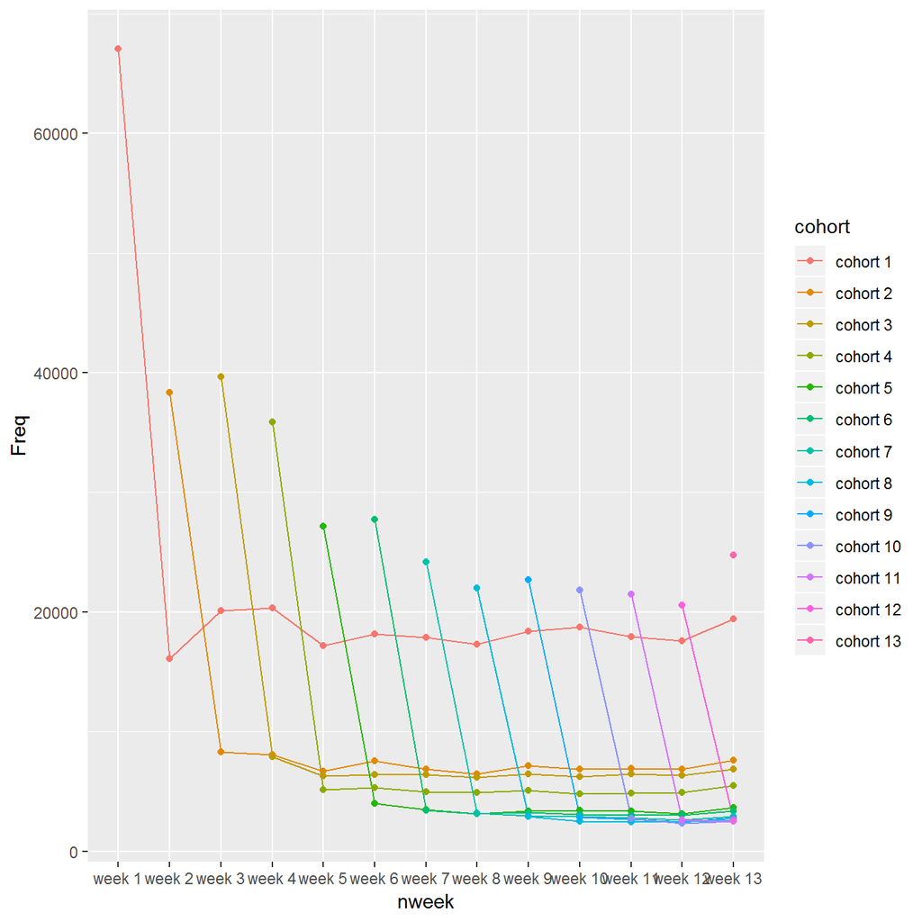

```r
  ggplot(lnd_retention, aes(x=nweek, y=Freq, group=cohort, colour=cohort)) +
    geom_line() + geom_point()
```

> - 집단별 매 주 재방문 건수 변화 시각화
> - 13주차 신규방문 집단은 재방문 기록 없음

```r
  mat_retentionRp <- data.frame(matrix(rep(NA,ncol(mat_retentionR)^2), ncol=ncol(mat_retentionR)))
  mat_retentionRm <- data.frame(matrix(rep(NA,ncol(mat_retentionR)^2), ncol=ncol(mat_retentionR)))
  for(j in 2:ncol(mat_retentionR)) {
    mat_retentionRp[,j] <- ifelse(mat_retentionR[,j]-mat_retentionR[,j-1]>0
                                  ,round(mat_retentionR[,j]-mat_retentionR[,j-1],4),"NA")
    mat_retentionRm[,j] <- ifelse(mat_retentionR[,j]-mat_retentionR[,j-1]<0
                                  & mat_retentionR[,j]-mat_retentionR[,j-1]>-0.5
                                  ,round(abs(mat_retentionR[,j]-mat_retentionR[,j-1]),4),"NA")
  }

  colnames(mat_retentionRp) <- colnames(mat_retentionR)
  colnames(mat_retentionRm) <- colnames(mat_retentionR)

  mat_retentionRp[is.na(mat_retentionRp)] <- "."
  mat_retentionRm[is.na(mat_retentionRm)] <- "."

  kable(mat_retentionRp) %>% kable_styling(font_size = 10)
```

| week 1 | week 2 | week 3 | week 4 | week 5 | week 6 | week 7 | week 8 | week 9 | week 10 | week 11 | week 12 | week 13 |
| --- | --- | --- | --- | --- | --- | --- | --- | --- | --- | --- | --- | --- |
| . | NA | 0.0597 | 0.0038 | NA | 0.0147 | NA | NA | 0.0169 | 0.0046 | NA | NA | 0.0272 |
| . | . | NA | NA | NA | 0.0222 | NA | NA | 0.0178 | NA | 0.0023 | NA | 0.0196 |
| . | . | . | NA | NA | 0.0032 | 0.0002 | NA | 0.0069 | NA | 0.0054 | NA | 0.0129 |
| . | . | . | . | NA | 0.0055 | NA | NA | 0.0048 | NA | 0.0013 | 0.0019 | 0.0157 |
| . | . | . | . | . | NA | NA | NA | 0.0099 | 0.0018 | NA | NA | 0.018 |
| . | . | . | . | . | . | NA | NA | 0.0043 | NA | NA | NA | 0.0127 |
| . | . | . | . | . | . | . | NA | NA | NA | NA | NA | 0.0114 |
| . | . | . | . | . | . | . | . | NA | NA | NA | 0.001 | 0.006 |
| . | . | . | . | . | . | . | . | . | NA | NA | NA | 0.0144 |
| . | . | . | . | . | . | . | . | . | . | NA | NA | 0.0069 |
| . | . | . | . | . | . | . | . | . | . | . | NA | NA |
| . | . | . | . | . | . | . | . | . | . | . | . | NA |
| . | . | . | . | . | . | . | . | . | . | . | . | . |

```r
  kable(mat_retentionRm) %>% kable_styling(font_size = 10)
```

| week 1 | week 2 | week 3 | week 4 | week 5 | week 6 | week 7 | week 8 | week 9 | week 10 | week 11 | week 12 | week 13 |
| --- | --- | --- | --- | --- | --- | --- | --- | --- | --- | --- | --- | --- |
| . | NA | NA | NA | 0.0471 | NA | 0.0049 | 0.0087 | NA | NA | 0.0121 | 0.0048 | NA |
| . | . | NA | 0.0055 | 0.0358 | NA | 0.0175 | 0.0103 | NA | 0.0079 | NA | 0.0024 | NA |
| . | . | . | NA | 0.0404 | NA | NA | 0.0061 | NA | 0.0053 | NA | 0.0035 | NA |
| . | . | . | . | NA | NA | 0.0101 | 0.0011 | NA | 0.0085 | NA | NA | NA |
| . | . | . | . | . | NA | 0.0186 | 0.0129 | NA | NA | 0.0027 | 0.0076 | NA |
| . | . | . | . | . | . | NA | 0.0105 | NA | 0.007 | 0.0002 | 0.0006 | NA |
| . | . | . | . | . | . | . | NA | 0.0106 | 0.0027 | 0.0048 | 0.0055 | NA |
| . | . | . | . | . | . | . | . | NA | 0.0184 | 0.0016 | NA | NA |
| . | . | . | . | . | . | . | . | . | NA | 0.0089 | 0.01 | NA |
| . | . | . | . | . | . | . | . | . | . | NA | 0.0177 | NA |
| . | . | . | . | . | . | . | . | . | . | . | NA | 0.0031 |
| . | . | . | . | . | . | . | . | . | . | . | . | NA |
| . | . | . | . | . | . | . | . | . | . | . | . | . |

> - 재방문율 증가시기와 감소시기 각각 확인
> - (재방문율 증가) 6주차, 9주차, 13주차
> - (재방문율 감소) 8주차, 10주차, 12주차